# Internet Connectivity and Usage Across the United States

# V. Other Interesting Visualizations

### Facebook Usage Across the US

- This tableau plot essentially shows the percentage of facebook users per state across the country. The states with a color that is more blue has a lower percentage of facebook users than states with a green color. States in the grey are more near the average percentage of users **Notice that the southeastern US tends to have a lower or average percentage of users with the exception of Georgia. Hawaii and Alaska also have some of the highest average amount of Facebook users as well.**

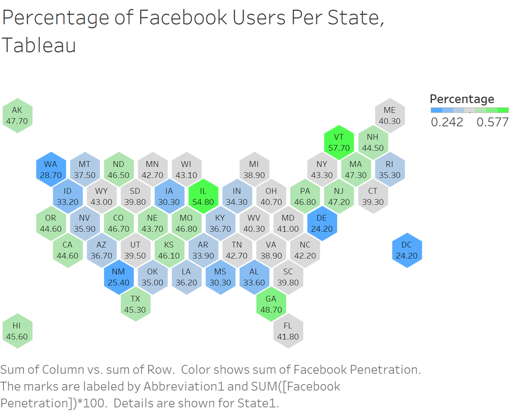

### Internet Usage at Work vs. Home

- This tableau plot essentially shows the amount of people who use the internet at work over the amount of people who use it at home. **The most interesting takeaway is how Washington DC has the highest percentage** This makes sense considering that this is the hub of government for the country.

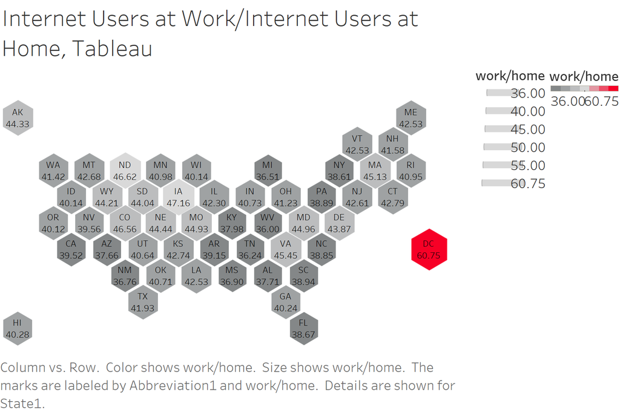

### State Per Capita Income with Internet Usage

- This tableau plot shows two variables for each state. The per capita income is represented by the size of the square whereas the internet usage for each state is represented by the color. The more green the square is the higher the usage of the internet. The more red the square the lower the internet usage. **The northeast area stands out as an area of high per capita income and high internet usage**

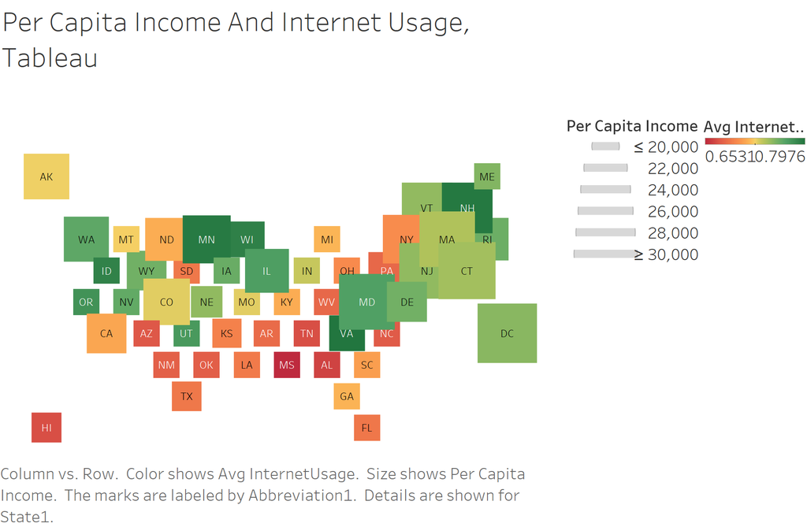